# act_report

### Reporting: Insights and visualizations

Analyzing the twitter_archive_master dataframe(the already assessed and cleaned dataset), i was able to make out three insights. I loaded in the new dataframe and ran a [correlation](https://en.wikipedia.org/wiki/Correlation) test on it using [df.corr](https://pandas.pydata.org/docs/reference/api/pandas.DataFrame.corr.html). From it i saw that the retweet count and favorite count has a correlation coefficient of 0.93 which indicates a strong positive correlation. This can also be interpreted that tweets with high favorite count has a corrresponding high retweet count. I also plotted a [scatter plot](https://byjus.com/maths/scatter-plot/#:~:text=Scatter%20plots%20are%20the%20graphs,plotted%20on%20the%20Y%2Daxis.) which made it very clear.

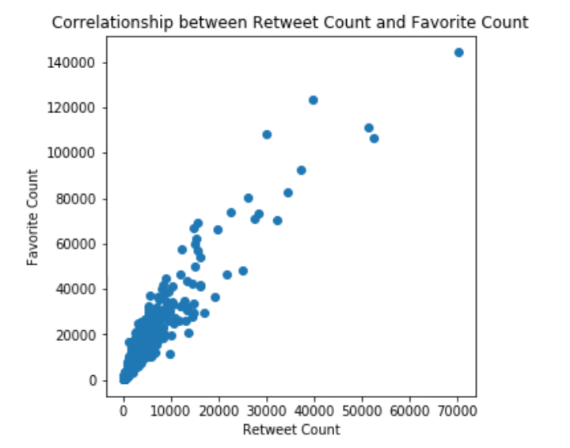

Moving on, i used [regex](https://regexone.com/lesson/wildcards_dot?) to specifically extract the actual tweet source from the source column into a new_source column. When i ran a [value_counts()](https://pandas.pydata.org/docs/reference/api/pandas.Series.value_counts.html) function on the new_source column, i found out that more persons tweeted fom their iphone than the Twitter web client(a twitter management tool) and the TweetDeck(a social media dashboard application). I also plotted a barchart to better communicate the finding.

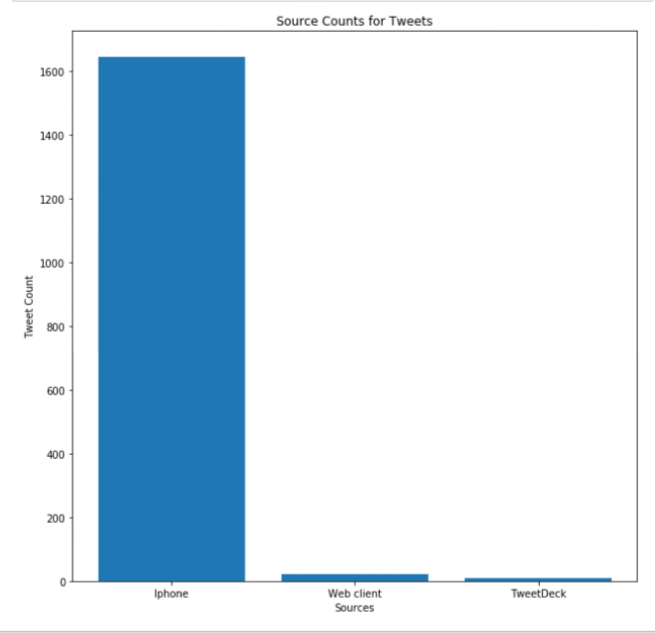

Finally, i wanted to see the dog stage with the most retweets. But, this was to be done for only those dogs with a known dog stage. So, i had to unpivot the four dog stage column into one. First, i made a copy of the dataframe then using the [melt](https://pandas.pydata.org/docs/reference/api/pandas.melt.html) function i unpivoted the four columns into one column named "stage" with it's corresponding value column and filtered it by the value column having no "None" in it. Working with this new dataframe, i checked the number of retweets each dog stage had using the [groupby](https://pandas.pydata.org/docs/reference/api/pandas.DataFrame.groupby.html) function and grouping by the stage column. From this, i saw that out of the four known dog stages; doggo, pupper, puppo, and floofer, the [pupper](https://video.udacity-data.com/topher/2017/October/59e04ceb_dogtionary-combined/dogtionary-combined.png) stage had the most number of retweets.